# Gene Ontology Analysis

Paul M. Magwene

February 25, 2016

# The clusterProfiler package

`clusterProfiler` is an R package for carrying out “Gene Ontology” (GO) and “Gene Set Enrichment Analysis” (GSEA). The goal of both of these techniques is to try to learn something about the likely functional roles of groups of genes identified by cluster analysis (or related techniques).

## Installing clusterProfiler

`clusterProfiler` is a package that is a part of a larger library of R tools called [Bioconductor](https://bioconductor.org). Bioconductor contains many different packages for helping to carry out bioinformatics tasks of various kinds.You were asked to install the `clusterProfiler` package before class (it takes a long time to build and install the vm-manage instances). If you ignored that advice, here’s the commands you’ll need to type at the console to install the package:

```r
source("https://bioconductor.org/biocLite.R")
```

and then

```r
biocLite("clusterProfiler")
```

Once the packages have installed you may get a prompt about updating some of the other libraries that are currently installed in your R instance. You should answer “No” (or “none”) to the question about updating, as the updates will also take a long time to install and don’t change key functionality that is relevant to the analyses you will undertake.

## Loading the package

Once installed you can load `clusterProfiler` just like any other R library.

```r
library(clusterProfiler)
```

## Install the Yeast GO database

Since our example involves a yeast (*Saccharomyces cerevisiae*) data set, we’ll need to install one additional package to make Gene Ontology available:

```r
source("https://bioconductor.org/biocLite.R")
biocLite("org.Sc.sgd.db")
```

# Creating clusters

We’ll need some gene clusters to work with. If you saved your workspace from previous days, you can use the clustering you’ve already created. If not, here’s a quick reminder on the steps for carrying out hierarchical clustering with the now familiar Spellman data set.

```r
yeast <- read.csv("spellman-tocluster.csv", row.names = 1, header = T)
my.dist <- function(x) {as.dist(1 - cor(x, use="pairwise.complete.obs"))}
yeast.dist <- my.dist(yeast)
yeast.clust <- hclust(yeast.dist, method="complete")
yeast.dend <- as.dendrogram(yeast.clust)
```

For variety, in the code above I used “complete linkage” clustering rather than the “average linkage” clustering method that I used in our previous class session.

Let’s generate a nice plot. First we bring in some nice libraries:

```r
library(dendextend)
library(RColorBrewer) # for nice color
```

and then we generate our plot:

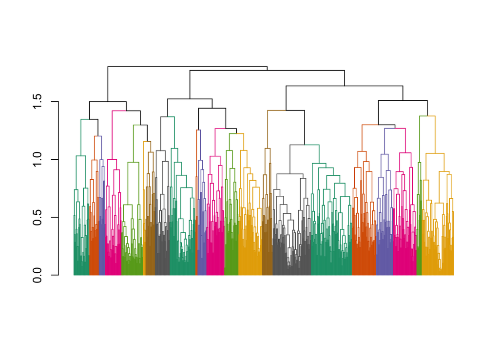

```r
color.dend <- color_branches(yeast.dend, h=1.1, col=brewer.pal(8,"Dark2"))
plot(color.dend, leaflab = "none")
```

Since the clusters look to be reasonably sized we’ll use that for now:

```r
clusters <- cutree(color.dend, h = 1.1, order_clusters_as_data = FALSE)
subtrees <- cut(color.dend, h = 1.1)
sort(table(clusters),decreasing = T)
```

```
## clusters
## 17 16 22  9 18 14 20  5 12 19  4  1  8 13 15  2  7 11  3 21  6 10
## 78 73 61 49 46 45 45 41 34 32 31 30 28 27 20 18 18 17 12 10  5  4
```

By specifying `order_clusters_as_data = FALSE` we insure that the clusters and corresponding subtrees match. The last line show the clusters sorted by size.

## About RColorBrewer

`RColorBrewer` is a package that supports easy specification of color palettes that are well designed for to help viewers distinguish differences in data. To see the available color schemes you can use the following command:

```r
display.brewer.all()
```

`RColorBrewer` on the work of a Cynthia Brewer, a geographer at Pennsylvania State University. See the [Color Brewer 2.0](http://colorbrewer2.org) web page for more info about these color schemes.

# From clusters to sets of gene names

To use `clusterProfilers` we need to get lists of genes. We saw last class that we could extract a list of labels from subtrees returned by `cut` using the `labels` function:

```r
labels(subtrees$lower[[1]])
```

```
##  [1] "YHR113W" "YIR036C" "YJL067W" "YNL134C" "YML100W" "YKL103C" "YDR368W"
##  [8] "YCL040W" "YCL042W" "YFR015C" "YOR230W" "YBR204C" "YDL089W" "YGL028C"
## [15] "YER124C" "YHR143W" "YLR286C" "YBR158W" "YGR044C" "YGR086C" "YLR079W"
## [22] "YNL327W" "YNR067C" "YGR041W" "YJL078C" "YNL015W" "YOR317W" "YNL173C"
## [29] "YOR263C" "YOR264W"
```

However, typing all that text every time we want to look at cluster is a little tedious, so we’re going to use a function called `lapply` to extract our gene names for all the subtrees at once. `lapply` applies a given function to all the elements of a list.

```r
gene.clu <- lapply(subtrees$lower, labels)
```

Now we can get the genes in each cluster like so:

```r
gene.clu[[2]] # get cluster 2 genes
```

```
##  [1] "YNR066C" "YML117W" "YHR030C" "YIL117C" "YKR091W" "YMR278W" "YHR006W"
##  [8] "YLR225C" "YMR055C" "YDR448W" "YNL003C" "YEL060C" "YOL016C" "YKL065C"
## [15] "YNL208W" "YPL054W" "YOR250C" "YPR107C"
```

# Using clusterProfiler

Documentation describing the user of `clusterProfiler` documentation is available [here](http://bioconductor.org/packages/release/bioc/html/clusterProfiler.html).

For our purposes we’ll primarily use two key functions defined in `clusterProfiler` – `groupGO` and `enrichGO`. `groupGO` finds the set of Gene Ontology terms that are associated with genes in a cluster. `enrichGO` identifies which GO terms are statistically enriched, relative to what you would expect by chance, using the Hypergeometric Test that we discussed in lecture.

Both functions are called in similar ways. We’ll look at `groupGO` first.

```r
ggo1 <- groupGO(gene         = gene.clu[[1]],
                organism     = "yeast",
                ont          = "BP",
                level        = 3,
                readable     = TRUE)

head(summary(ggo1))
```

```
##                    ID                              Description Count
## GO:0019953 GO:0019953                      sexual reproduction     2
## GO:0019954 GO:0019954                     asexual reproduction     0
## GO:0032504 GO:0032504      multicellular organism reproduction     0
## GO:0032505 GO:0032505 reproduction of a single-celled organism     0
## GO:0051321 GO:0051321                       meiotic cell cycle     2
## GO:0006807 GO:0006807      nitrogen compound metabolic process     5
##            GeneRatio
## GO:0019953      2/30
## GO:0019954      0/30
## GO:0032504      0/30
## GO:0032505      0/30
## GO:0051321      2/30
## GO:0006807      5/30
##                                                            geneID
## GO:0019953                                  S000000926/S000005117
## GO:0019954
## GO:0032504
## GO:0032505
## GO:0051321                                  S000005756/S000003276
## GO:0006807 S000000545/S000005756/S000002247/S000004276/S000003276
```

The argument `ont` specifies the type of sub-ontology to use. The possible options for `ont` are “BP” (biological process), “MF” (molecular function), and “CC” (cellular component). `level` species the GO level (higher levels are narrower ontology terms and take longer to process). If `TRUE`, the `readable` argument maps gene IDs to gene names (when available).

# GO Enrichment

While `groupGO` just gives you the gene ontology information for a set of genes at a given GO level, `enrichGO` will carry out a statistical test to identify GO terms that are “over represented” in a set of genes (occur higher than you would expect by chance). To carry such an analysis you need not only a list of genes from a cluster of interest, but some notion of a “universe” of genes and associated GO terms that represent the appropriate “background” to compare to. If you don’t specify a `universe` argument, `enrichGO` will default to treating all genes in the genome of the given organism as the universe.

Let’s apply `enrichGO` to cluster 22.

```r
ego22 <- enrichGO(gene        = gene.clu[[22]],
                organism      = "yeast",
                ont           = "BP",
                pAdjustMethod = "BH",
                pvalueCutoff  = 0.01,
                qvalueCutoff  = 0.05,
                readable      = TRUE)

head(summary(ego22))
```

```
##                    ID                       Description GeneRatio BgRatio
## GO:0006333 GO:0006333 chromatin assembly or disassembly     10/59 67/6380
## GO:0006486 GO:0006486             protein glycosylation      8/59 68/6380
## GO:0043413 GO:0043413       macromolecule glycosylation      8/59 68/6380
## GO:0070085 GO:0070085                     glycosylation      8/59 70/6380
## GO:0009101 GO:0009101 glycoprotein biosynthetic process      8/59 73/6380
## GO:0009100 GO:0009100    glycoprotein metabolic process      8/59 74/6380
##                  pvalue     p.adjust       qvalue
## GO:0006333 3.412642e-10 2.457102e-07 2.036809e-07
## GO:0006486 1.574577e-07 3.568146e-05 2.957805e-05
## GO:0043413 1.574577e-07 3.568146e-05 2.957805e-05
## GO:0070085 1.982303e-07 3.568146e-05 2.957805e-05
## GO:0009101 2.762610e-07 3.690441e-05 3.059182e-05
## GO:0009100 3.075368e-07 3.690441e-05 3.059182e-05
##                                                                                                                   geneID
## GO:0006333 S000000098/S000000099/S000000213/S000000214/S000002632/S000002633/S000003175/S000004975/S000004976/S000006048
## GO:0006486                       S000002213/S000002251/S000002253/S000002715/S000000768/S000000803/S000000805/S000003006
## GO:0043413                       S000002213/S000002251/S000002253/S000002715/S000000768/S000000803/S000000805/S000003006
## GO:0070085                       S000002213/S000002251/S000002253/S000002715/S000000768/S000000803/S000000805/S000003006
## GO:0009101                       S000002213/S000002251/S000002253/S000002715/S000000768/S000000803/S000000805/S000003006
## GO:0009100                       S000002213/S000002251/S000002253/S000002715/S000000768/S000000803/S000000805/S000003006
##            Count
## GO:0006333    10
## GO:0006486     8
## GO:0043413     8
## GO:0070085     8
## GO:0009101     8
## GO:0009100     8
```

The new arguments above – `pAdjustMethod`, `pvalueCutoff`, and `qvalueCutoff` – specify the statistical cutoffs you want to apply in terms of decided when a term is considered as enriched. The values above are reasonable defaults.

From the summary we see that the top GO term is “chromatin assembly or dissasembly”, and this term is associated with 10 out of 59 genes in the cluster.

We can write the summary data for a GO enrichment out to a CSV file like so:

```r
write.csv(summary(ego22), "yeast-cluster22-GO.csv")
```

## Visualizing GO enrichment results

`clusterProfiler` has a number of built in functions for visualizing the output of `enrichGO`.

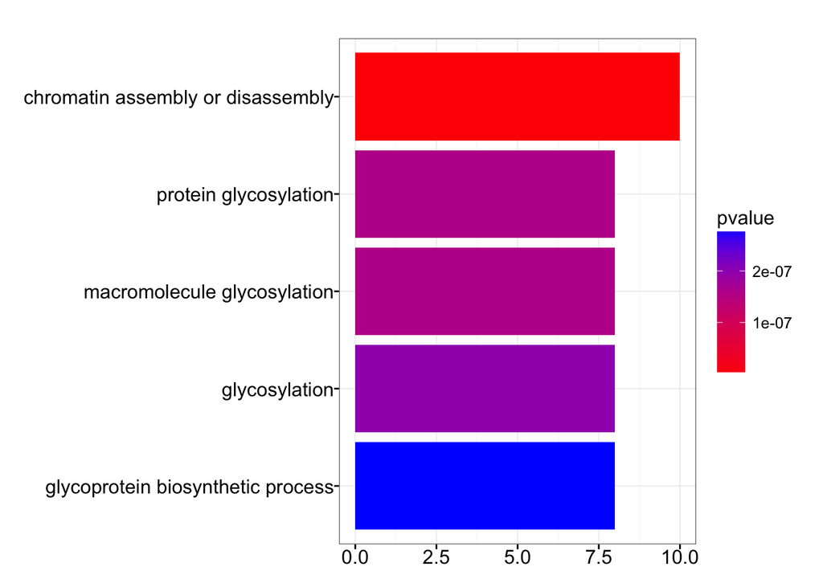

```r
barplot(ego22)
```

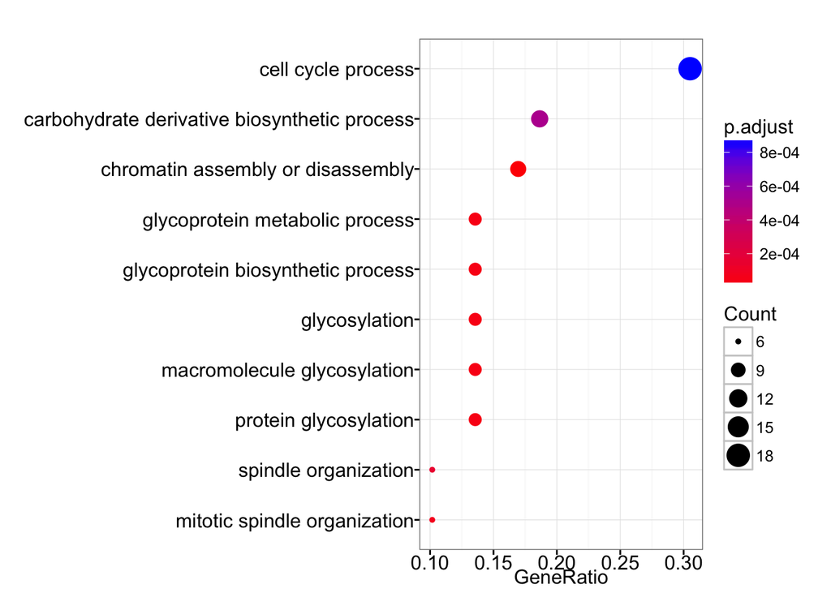

```r
dotplot(ego22)
```

## Applying GO enrichment to all clusters

`clusterProfiler` has a function called `compareCluster` that allows you to apply the `enrichGO` function to multiple clusters simulataneously.

To use the `compareCluster` function, we must have a list of named clusters. We can add names to our `gene.clu` list as follows:

```r
 names(gene.clu) <- paste("cluster", 1:22,sep="")
```

Now that our clusters are named we can call the `compareCluster` function in a manner analogous to `enrichGo`:

```r
cc <- compareCluster(gene     = gene.clu,
                organism      = "yeast",
                ont           = "BP",
                pAdjustMethod = "BH",
                pvalueCutoff  = 0.01,
                qvalueCutoff  = 0.05,
                readable      = TRUE)
```

And then we can generate a plot to represent the enriched terms in all the clusters:

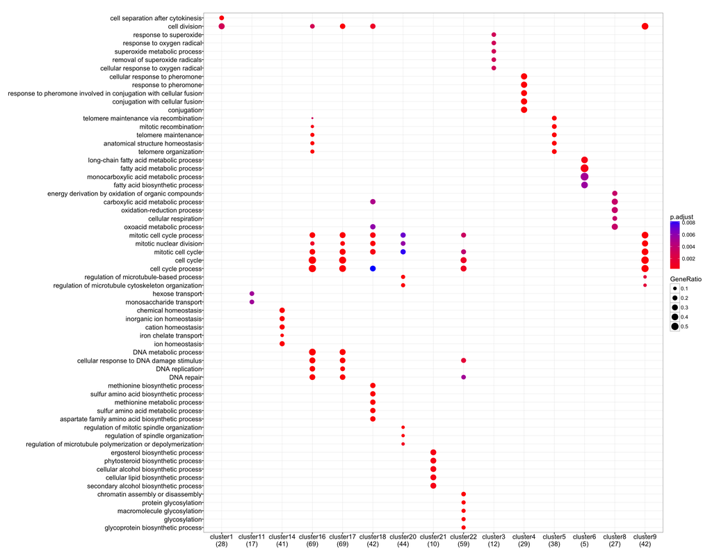

```r
plot(cc)
```

The default scaling and size of your figure might not be pleasing. You can explicitly set figure sizes like so:

```r
pdf("yeast-GO-figure.pdf", width=18, height=14)
plot(cc)
dev.off()
```

If instead you wanted to save it as a PNG file you would do:

```r
png("yeast-GO-figure.png", width=18, height=14)
plot(cc)
dev.off()
```

## GO analysis on less standard model organisms

`clusterProfiler` has built in support for some of the most frequently studied organisms.

The built in set of supported organisms, as of Feb 2016, is:

```
"anopheles", "arabidopsis", "bovine", "canine", "celegans", "chicken", "chimp", "coelicolor", "ecolik12","ecsakai", "fly", "gondii","human", "malaria", "mouse", "pig", "rat","rhesus", "xenopus", "yeast" and "zebrafish".
```

What if you want to work with an organism not included in this list? `clusterProfiler` includes a function called `enricher` which carries out the same basic hypergeometric test of gene set enrichment for arbitrary GO mappings. You will need to call `enricher` with a universe of background genes, as well as two data frames – one mapping GO IDs to genes, and the other mapping GO IDs to GO names. See the `clusterProfiler` help for more info.